# Final Project

### Introduction to Weather Prediction Using Data Science

#### Understanding the Data Science Pipeline Through Weather Analysis

This tutorial, explores the process of data analysis, step by step. Our focus is on leveraging data from the National Centers for Environmental Information to predict weather conditions based on a variety of meteorological variables. This tutorial aims not only to educate on the technical aspects of data science but also to demonstrate how these skills can be applied to real-world problems that can affect daily lives and safety.

#### Why Weather Prediction?

The importance of weather prediction extends beyond mere academic interest; it is crucial for disaster management, agriculture, urban planning, and even for individuals planning their daily activities. Accurate weather predictions can help mitigate the effects of extreme weather events, and reduce economic losses. With the growing impacts of climate change, the ability to predict weather accurately is becoming more critical. By understanding and forecasting weather conditions, we can better prepare for and respond to the environmental challenges posed by a changing climate.

#### Choosing the Variables

For this project, several key weather variables that are instrumental in forecasting different weather conditions were selected. These include:

- **Average Wind Speed:** Wind speed influences weather patterns and is a critical factor in storm formation and dispersion. It transports moisture and heat across the Earth's surface, influencing humidity levels and temperature distribution
- **Total Precipitation:** Precipitation is a primary indicator of various weather conditions as it directly affects the amount of moisture in the atmosphere and influences temperature patterns
- **Maximum, Minimum, and Average Temperature:** Temperatures are fundamental to defining climate zones and weather patterns and are crucial for predicting seasonal variations and heatwaves.

These variables were chosen based on their significant impact on weather phenomena and their interrelationships, which allow for the construction of a predictive model that can forecast various weather conditions based on historical data.

#### Tutorial Outline

The tutorial will cover the following key stages of the data science lifecycle:

1. **Data Collection:** Retrieve and organize weather data from authoritative sources, ensuring accuracy and relevance to weather prediction objectives.
2. **Data Processing:** This stage involves cleaning and structuring the data, making it suitable for analysis and modeling.
3. **Exploratory Analysis & Data Visualization:** Explore the data visually to understand trends, patterns, and outliers.
4. **Model Building (Analysis, Hypothesis Testing, & ML):** Develop machine learning models to predict weather conditions, testing various hypotheses about the relationships between different variables.
5. **Interpretation and Insights:** The final step will be to interpret the model results and extract actionable insights, translating our findings into understandable and useful conclusions.

By the end of this tutorial, you will have a solid understanding of how to apply data science techniques to real-world problems, specifically in the context of weather prediction, using Python and tools like Jupyter Notebooks.

```python
### Data Collection

The tutorial includes direct data collection from the National Centers for Environmental Information via their API. An API key is required to authenticate requests. In the provided Python code, an API key is stored in the variable `api_key` and a base URL `https://www.ncei.noaa.gov/cdo-web/api/v2/data` specifies the endpoint for data requests.

Parameters for the API call are defined in the `params` dictionary. This includes specifying the dataset ID (`GSOY` for Global Summary of the Year), data types such as average wind speed (`AWND`), days with fog (`DYFG`), heavy fog (`DYHF`), thunderstorms (`DYTS`), precipitation (`PRCP`), snow (`SNOW`), average temperature (`TAVG`), maximum temperature (`TMAX`), minimum temperature (`TMIN`), and total sunshine (`TSUN`). The date range for the data is set to a single day on January 1, 1900, which should be adjusted based on the actual data requirements. The `limit` parameter is set to 1000 entries, and specific station IDs are provided to target data collection from those locations.

Headers containing the API key are passed along with the base URL and parameters to make a GET request using the `requests.get` method. The response from this request is then converted into JSON format, and the relevant data is normalized into a pandas DataFrame `df` using `pd.json_normalize`. This DataFrame `df` is then previewed using `df.head()` to display the first few entries.

Additionally, local CSV files also can be directly downloaded from the website and get loaded into pandas DataFrames `df1`, `df2`, and `df3` from specified paths. These files contain data from specific weather stations, as indicated by the file names. Previews of these DataFrames are shown using the `print(df1.head())`, `print(df2.head())`, and `print(df3.head())` commands to display the top entries and ensure the data has been loaded correctly. This multi-source approach allows the analysis of both real-time API data and historical data from local files, catering to a comprehensive study in weather prediction.
```

```python
import pandas as pd
import pandas as pd
from sklearn.preprocessing import StandardScaler
import numpy as np
import matplotlib.pyplot as plt
import seaborn as sns
from scipy.stats import pearsonr, ttest_ind
import numpy as np
import pandas as pd
import matplotlib.pyplot as plt
import seaborn as sns
from sklearn.model_selection import train_test_split, cross_val_score, KFold
from sklearn.preprocessing import StandardScaler
from sklearn.tree import DecisionTreeRegressor
from sklearn.svm import SVR
from sklearn.neighbors import KNeighborsRegressor
from sklearn.neural_network import MLPRegressor
from sklearn.ensemble import GradientBoostingRegressor
from sklearn.metrics import mean_squared_error, mean_absolute_error, r2_score
import statsmodels.api as sm
import statsmodels.formula.api as smf
```

```python
# Data Collection directly from the website using API key
api_key = 'api_key'
base_url = "https://www.ncei.noaa.gov/cdo-web/api/v2/data"

# parameters for the API call
params = {
    'datasetid': 'GSOY',
    'datatypeid': ['AWND', 'DYFG', 'DYHF', 'DYTS', 'PRCP', 'SNOW', 'TAVG', 'TMAX', 'TMIN', 'TSUN'],
    'startdate': '1900-01-01',
    'enddate': '1900-01-01',
    'limit': 1000,
    'stationid': ['GHCND:USW00023065', 'GHCND:USW00023066', 'GHCND:USW00003103']
}

headers = {
    'token': api_key
}

response = requests.get(base_url, headers=headers, params=params)
data = response.json()

df = pd.json_normalize(data['results'])

print(df.head())

df1 = pd.read_csv(r'C:\Users\elena\Downloads\USW00023065(2).csv')
df2 = pd.read_csv(r'C:\Users\elena\Downloads\USW00023066(2).csv')
df3 = pd.read_csv(r'C:\Users\elena\Downloads\USW00003103(2).csv')
# Preview the data
print(df1.head())
print(df2.head())
print(df3.head())
```

```
       STATION  DATE  LATITUDE  LONGITUDE  ELEVATION  \
0  USW00023065  1896  39.36729 -101.69322     1110.5
1  USW00023065  1911  39.36729 -101.69322     1110.5
2  USW00023065  1914  39.36729 -101.69322     1110.5
3  USW00023065  1915  39.36729 -101.69322     1110.5
4  USW00023065  1916  39.36729 -101.69322     1110.5

                           NAME  AWND AWND_ATTRIBUTES   CDSD  CDSD_ATTRIBUTES  \
0  GOODLAND RENNER FIELD, KS US   NaN             NaN    NaN              NaN
1  GOODLAND RENNER FIELD, KS US   NaN             NaN    NaN              NaN
2  GOODLAND RENNER FIELD, KS US   NaN             NaN    NaN              NaN
3  GOODLAND RENNER FIELD, KS US   NaN             NaN  199.5              NaN
4  GOODLAND RENNER FIELD, KS US   NaN             NaN  511.4              NaN

   ...  WDFG WDFG_ATTRIBUTES  WSF1 WSF1_ATTRIBUTES  WSF2 WSF2_ATTRIBUTES  \
```

[output cut: 72 more lines]

```python
### Data Processing

The data processing steps in the provided Python code are essential for preparing the dataset for further analysis and machine learning. These steps ensure that the data is consistent, clean, and suitable for modeling. Here's a detailed explanation of each step and the rationale behind it:

1. **Combining DataFrames**: The code begins by aggregating data from multiple sources, represented by `df1`, `df2`, and `df3` into a list called `dataframes`. This is crucial for creating a comprehensive dataset that incorporates varied measurements from different locations.

2. **Defining Relevant Columns**: A list named `relevant_columns` specifies which columns to retain in the analysis. This includes dates, temperature measurements, precipitation, snow, wind speed, and other relevant weather variables. Focusing on these columns helps streamline the dataset by excluding unnecessary information, which can reduce complexity and improve processing efficiency.

3. **Cleaning Individual DataFrames**:
    - **Column Filtering**: Each dataframe is filtered to keep only the relevant columns. This ensures consistency across different datasets and focuses the analysis on essential variables.
    - **Handling Missing Values**: Rows missing critical data (`DATE` or `STATION`) are removed because these fields are necessary for tracking and grouping the data correctly. Other missing values are filled with the median of their respective columns, which is a robust measure of central tendency that minimizes the impact of outliers.
    - **Dealing with Outliers**: Values in each column are capped at the 1st and 99th percentiles. This method reduces the effect of extreme outliers, which can skew the analysis and lead to inaccurate models.

4. **Merging DataFrames**: After cleaning, all individual dataframes are combined into a single dataframe `merged_df` using `pd.concat`, with `ignore_index=True` to reindex the new dataframe. This step is vital for creating a unified dataset that facilitates comprehensive analysis.

5. **Column Verification**: Printing the columns of `merged_df` helps verify that the merge was successful and that all relevant columns are included.

6. **Data Normalization**:
    - **Standard Scaling**: The `StandardScaler` is applied to temperature, precipitation, snow, wind speed, and other weather-related measurements. Normalization (or standardization) is critical in data preprocessing, especially before machine learning, as it scales the data to have zero mean and unit variance, thereby ensuring that no single feature dominates others due to its scale.

The final output, `merged_df.head()`, is used to display the first few entries of the processed and normalized dataset. This allows for a quick inspection to ensure that the data looks correct and is ready for the next stages of exploratory data analysis or model building.
```

```python
dataframes = [df1, df2, df3]

# List of relevant columns
relevant_columns = ['DATE', 'TMAX', 'TMIN', 'PRCP', 'SNOW', 'STATION', 'TAVG', 'AWND', 'DYHF', 'DYTS', 'TSUN', 'DYFG']

# Function to clean individual dataframe
def clean_data(df):
    # Filter relevant columns
    df = df[relevant_columns]

    # Handling missing values
    df = df.dropna(subset=['DATE', 'STATION'])
    for col in df.columns:
        if col not in ['DATE', 'STATION']:
            df[col].fillna(df[col].median(), inplace=True)

    # Dealing with the outliers
    for col in ['TMAX', 'TMIN', 'PRCP', 'SNOW', 'TAVG', 'AWND', 'DYHF', 'DYTS', 'TSUN', 'DYFG']:
        if col in df.columns:
            lower = df[col].quantile(0.01)
            upper = df[col].quantile(0.99)
            df[col] = np.clip(df[col], lower, upper)

    return df

# Cleaning all the dataframes
cleaned_dfs = [clean_data(df) for df in dataframes]

# Merging dataframes
merged_df = pd.concat(cleaned_dfs, ignore_index=True)
print("Columns in merged_df:", merged_df.columns)

# Data Normalization
scaler = StandardScaler()
cols_to_normalize = ['TMAX', 'TMIN', 'PRCP', 'SNOW', 'TAVG', 'AWND', 'DYHF', 'DYTS', 'TSUN', 'DYFG']
merged_df[cols_to_normalize] = scaler.fit_transform(merged_df[cols_to_normalize])

merged_df.head()
```

```
Columns in merged_df: Index(['DATE', 'TMAX', 'TMIN', 'PRCP', 'SNOW', 'STATION', 'TAVG', 'AWND',
       'DYHF', 'DYTS', 'TSUN', 'DYFG'],
      dtype='object')
```

|  | DATE | TMAX | TMIN | PRCP | SNOW | STATION | TAVG | AWND | DYHF | DYTS | TSUN | DYFG |
| --- | --- | --- | --- | --- | --- | --- | --- | --- | --- | --- | --- | --- |
| 0 | 1896 | 0.502294 | 0.182265 | 0.401459 | -0.372185 | USW00023065 | 0.249725 | 1.351162 | 0.999855 | 0.595631 | -0.778816 | -1.826914 |
| 1 | 1911 | 0.502294 | 0.182265 | 0.401459 | -0.372185 | USW00023065 | 0.249725 | 1.351162 | 0.999855 | 0.595631 | -0.778816 | -1.664577 |
| 2 | 1914 | 0.502294 | 0.182265 | 0.401459 | -0.372185 | USW00023065 | 0.249725 | 1.351162 | 0.999855 | 0.595631 | -0.778816 | -1.859381 |
| 3 | 1915 | -0.777743 | -0.240271 | 0.401459 | -0.372185 | USW00023065 | -0.463556 | 1.351162 | 0.999855 | 0.595631 | -0.778816 | 1.013983 |
| 4 | 1916 | 0.556380 | -0.619411 | -0.664136 | -0.372185 | USW00023065 | -0.170024 | 1.351162 | 0.999855 | 0.595631 | -0.778816 | -1.859381 |

### Time Series Analysis in Data Science

The provided code segment performs essential transformations and visualizations for time series analysis of temperature data. First, the 'DATE' column in the dataframe `merged_df` is converted to a numeric format to ensure proper handling of time data. The `sns.set(style='whitegrid')` command sets a visually clean style for the plots that follow. The data is then aggregated annually, focusing only on numeric columns to compute the mean of temperatures and other relevant variables per year. This aggregation is critical for visualizing changes over time, reducing noise, and highlighting broader trends.

Time series plots are created for maximum (TMAX), minimum (TMIN), and average (TAVG) temperatures. Each plot uses matplotlib's `plt.plot` function to graph these temperatures against the years, showcasing how these metrics have evolved. These plots are instrumental in identifying patterns, trends, and anomalies in temperature data over time, such as warming trends or unusual fluctuations. By visualizing these changes, one can infer the effects of seasonal variations, climate change, or other external factors impacting temperature dynamics. This type of visualization is not only key for weather prediction but also for understanding broader environmental changes.

### Understanding Time Series Plots

A time series plot is a graphical representation that shows how a set of data points vary over time. It is typically used to observe trends, cycles, or seasonal variations in data. In the context of climate data, time series plots can reveal crucial information about the progression of weather conditions over the years, helping analysts and scientists detect warming trends, predict future climate conditions, and assess the effectiveness of environmental policies. By examining these plots, one can gain insights into the temporal dynamics of weather variables, which is essential for any form of longitudinal climate-related study.

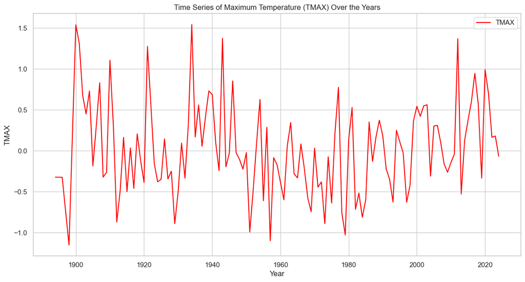

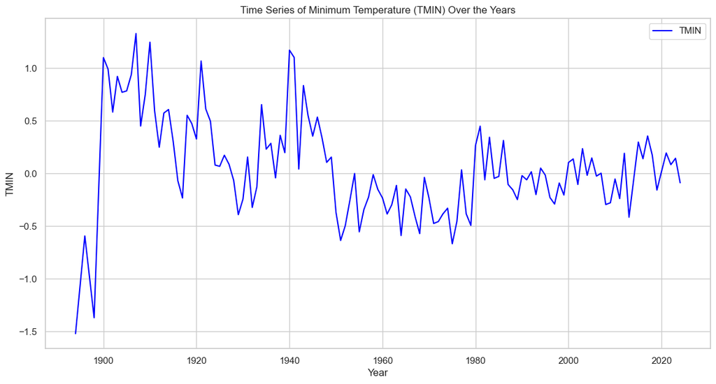

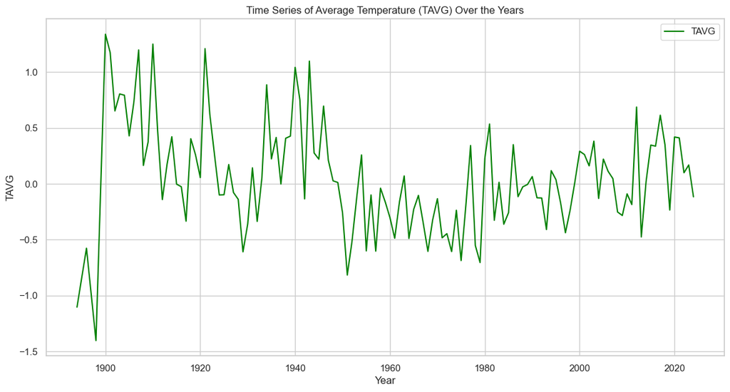

```python
merged_df['DATE'] = pd.to_numeric(merged_df['DATE'], errors='coerce')

# Setting the style for the plots
sns.set(style='whitegrid')

# Aggregating data by year
numeric_columns = merged_df.select_dtypes(include=['float64', 'int64']).columns.drop('DATE')
annual_data = merged_df.groupby('DATE')[numeric_columns].mean().reset_index()

# 1. Time series plots of temperature over the years

# Time series plot for TMAX
plt.figure(figsize=(14, 7))
plt.plot(annual_data['DATE'], annual_data['TMAX'], label='TMAX', color='red')
plt.title('Time Series of Maximum Temperature (TMAX) Over the Years')
plt.xlabel('Year')
plt.ylabel('TMAX')
plt.legend()
plt.show()

# Time series plot for TMIN
plt.figure(figsize=(14, 7))
plt.plot(annual_data['DATE'], annual_data['TMIN'], label='TMIN', color='blue')
plt.title('Time Series of Minimum Temperature (TMIN) Over the Years')
plt.xlabel('Year')
plt.ylabel('TMIN')
plt.legend()
plt.show()

# Time series plot for TAVG
plt.figure(figsize=(14, 7))
plt.plot(annual_data['DATE'], annual_data['TAVG'], label='TAVG', color='green')
plt.title('Time Series of Average Temperature (TAVG) Over the Years')
plt.xlabel('Year')
plt.ylabel('TAVG')
plt.legend()
plt.show()
```

### Heatmap

Heatmap Showing Temperature Changes Across Different Regions (Stations): This heatmap visualizes the average temperature changes over the years for different weather stations. It helps to see regional variations and trends in temperature.

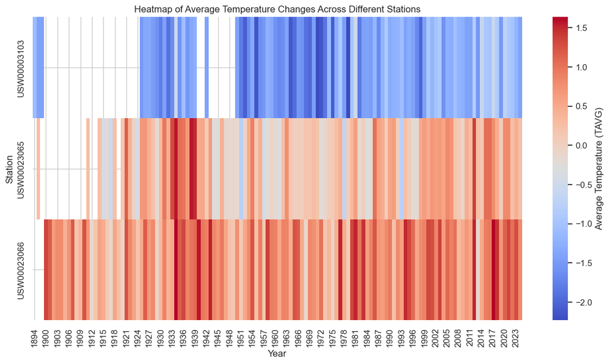

```python
# 2. Heatmap showing temperature changes across different regions (stations)
pivot_table = merged_df.pivot_table(index='DATE', columns='STATION', values='TAVG', aggfunc='mean')
plt.figure(figsize=(14, 7))
sns.heatmap(pivot_table.T, cmap='coolwarm', cbar_kws={'label': 'Average Temperature (TAVG)'})
plt.title('Heatmap of Average Temperature Changes Across Different Stations')
plt.xlabel('Year')
plt.ylabel('Station')
plt.show()
```

### Understanding Pearson Correlation

Pearson correlation is a statistic that measures the linear correlation between two variables, providing a value between -1 and 1. This value represents the extent to which two variables increase or decrease in parallel; a coefficient close to 1 means that they have a strong positive correlation, a coefficient close to -1 indicates a strong negative correlation, and a coefficient around 0 implies no linear correlation. This metric is crucial in data analysis for identifying relationships between variables, which can help in feature selection and understanding underlying patterns in the data.

### Interpreting the Pearson Correlation Matrix

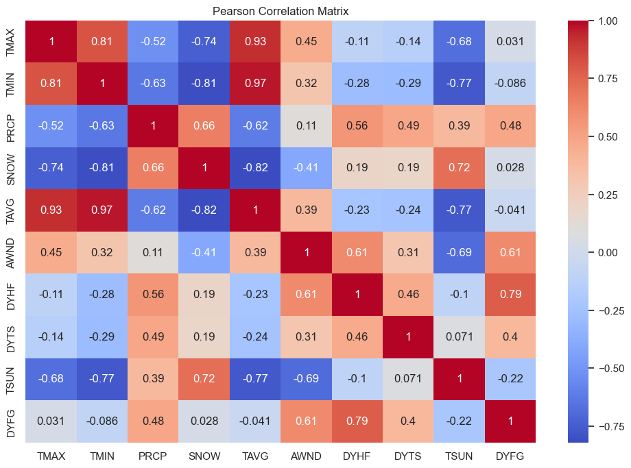

```python
# 3. Pearson correlation plot
numeric_columns = merged_df.select_dtypes(include=['float64', 'int64']).columns.drop(['DATE'])

# Calculating the Pearson correlation matrix
correlation_matrix = merged_df[numeric_columns].corr()

# Plotting Pearson correlation matrix
plt.figure(figsize=(12, 8))
sns.heatmap(correlation_matrix, annot=True, cmap='coolwarm')
plt.title('Pearson Correlation Matrix')
plt.show()
```

### Understanding Histograms

A histogram is a graphical representation used to estimate the probability distribution of a continuous or discrete variable. It displays the frequency of data points within specified ranges (bins). Each bin represents a range of values, and the height of each bin indicates the number of data points that fall within that range. Histograms are crucial for identifying distributions, spotting outliers, understanding the spread of the data, and detecting the presence of multiple modes in the data.

### Interpreting the Histogram Results

Each histogram is enhanced with a Kernel Density Estimate (KDE) overlay, providing a smooth curve that helps in understanding the underlying distribution trend beyond the individual bins of the histogram.

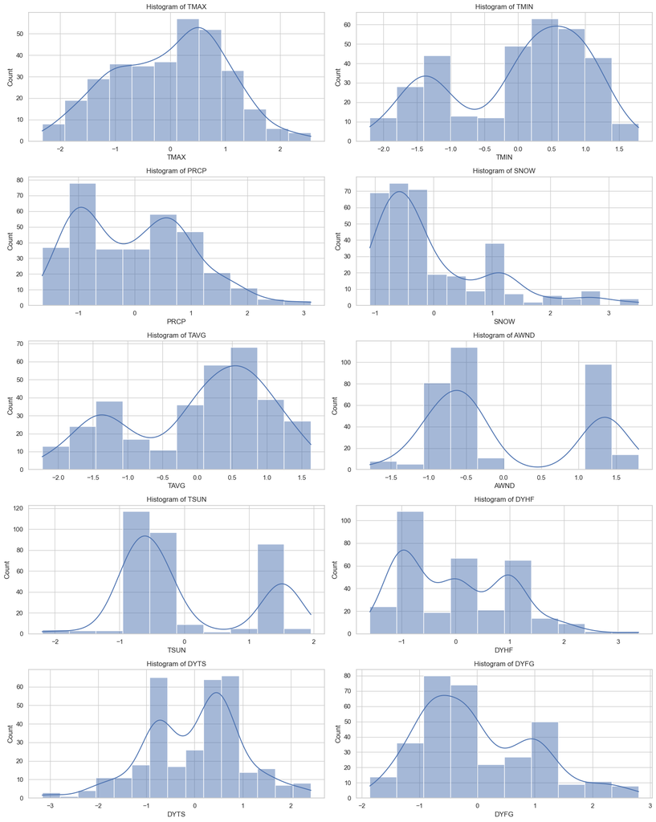

```python
# 5. Histogram of variables in different subplots and colors
variables = ['TMAX', 'TMIN', 'PRCP', 'SNOW', 'TAVG', 'AWND', 'TSUN','DYHF', 'DYTS','DYFG']
plt.figure(figsize=(16, 20))
for i, var in enumerate(variables):
    plt.subplot(5, 2, i+1)
    sns.histplot(merged_df[var], kde=True)
    plt.title(f'Histogram of {var}')
plt.tight_layout()
plt.show()
```

### Understanding Violin Plots

A violin plot is a method of plotting numeric data and can be thought of as a combination of a box plot and a kernel density plot. It provides a visual summary of the data showing peaks, distributions, and tails. The wider sections of the violin plot represent a higher probability that members of the population will take on the given value; the slimmer sections represent a lower probability. The white dot in the middle of the violin indicates the median, and the thick black bar in the center represents the interquartile range. These plots are particularly useful for comparing distributions between multiple groups, variables, or datasets.

### Interpreting the Violin Plot Results

Overall, these violin plots are effective in showing the full distribution of data, which helps in understanding not only the central tendency and variability but also the shape of the data distribution.

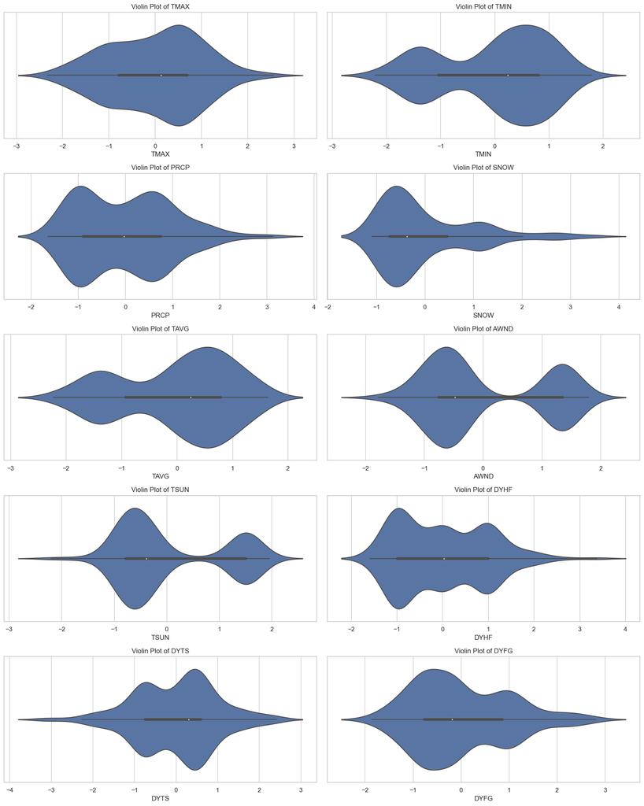

```python
# Violin plots in separate subplots
variables = ['TMAX', 'TMIN', 'PRCP', 'SNOW', 'TAVG', 'AWND', 'TSUN', 'DYHF', 'DYTS', 'DYFG']
plt.figure(figsize=(16, 20))
for i, var in enumerate(variables):
    plt.subplot(5, 2, i+1)
    sns.violinplot(data=merged_df, x=var)
    plt.title(f'Violin Plot of {var}')
plt.tight_layout()
plt.show()
```

### Understanding Box Plots

A box plot, also known as a box-and-whisker plot, is a standardized way of displaying the distribution of data based on a five-number summary: minimum, first quartile (Q1), median, third quartile (Q3), and maximum. It is useful for indicating whether a distribution is skewed and whether there are potential unusual observations (outliers) in the data set. Box plots display the full range of variation (from min to max), the likely range of variation (the IQR: interquartile range), and a typical value (the median). Notably, outliers are plotted as individual points which occur outside the whiskers (whiskers typically cover 1.5 * IQR from the quartiles).

### Interpreting the Box Plot Results

These box plots are essential for understanding the central tendency, variability, and presence of outliers in the data related to weather conditions.

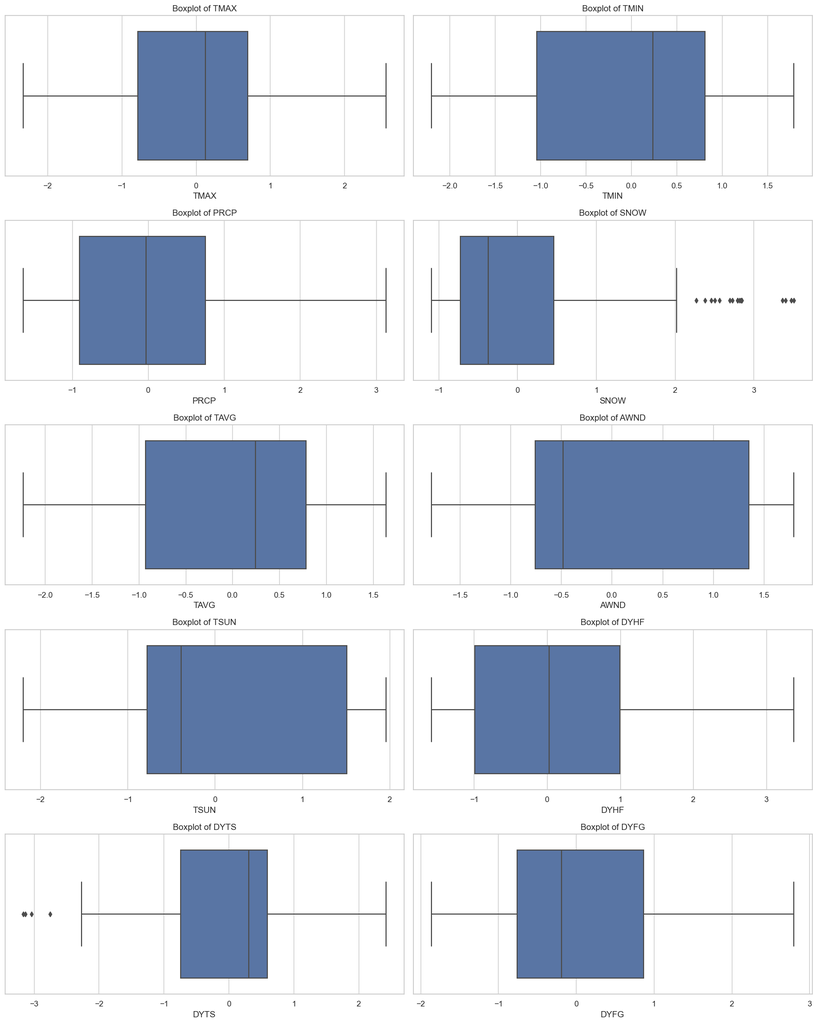

```python
# 7. Boxplots for skewness
plt.figure(figsize=(16, 20))
for i, var in enumerate(variables):
    plt.subplot(5, 2, i+1)
    sns.boxplot(x=merged_df[var])
    plt.title(f'Boxplot of {var}')
plt.tight_layout()
plt.show()
```

### Understanding Scatter Plots and Statistical Metrics

Scatter plots are graphical representations that show the relationship between two variables, allowing for a visual assessment of their correlation. Each point on the plot corresponds to a pair of values, making it possible to detect patterns, trends, or any anomalies in the relationship between the variables. The correlation coefficient (Corr) quantifies the degree to which these variables are related. A correlation close to 1 or -1 indicates a strong relationship, while a value near 0 suggests a weak relationship.

### Interpreting the Scatter Plot Results

These scatter plots, enhanced with statistical metrics, are essential for understanding how different weather phenomena interact with temperatures, which is crucial for predictive modeling and climate studies.

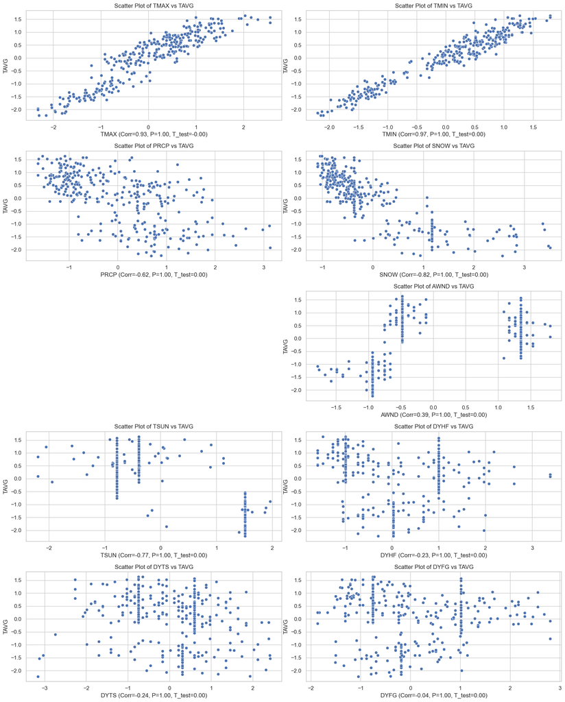

```python
# 8. Scatter plot of each variable with their Pearson correlation number, T-test, and P-value
plt.figure(figsize=(16, 20))
for i, var in enumerate(variables):
    if var != 'TAVG':
        plt.subplot(5, 2, i+1)
        sns.scatterplot(x=merged_df[var], y=merged_df['TAVG'])
        plt.title(f'Scatter Plot of {var} vs TAVG')
        correlation, _ = pearsonr(merged_df[var].dropna(), merged_df['TAVG'].dropna())
        t_stat, p_value = ttest_ind(merged_df[var].dropna(), merged_df['TAVG'].dropna())
        plt.xlabel(f'{var} (Corr={correlation:.2f}, P={p_value:.2f}, T_test={t_stat:.2f})')
plt.tight_layout()
plt.show()
```

### Analysis of Weather Variables Through Regression Results

#### Hypothesis 1: Higher precipitation leads to more thunderstorm days (DYTS)

The Ordinary Least Squares (OLS) regression results for the relationship between precipitation and thunderstorm days show a positive coefficient of 0.486 for precipitation (PRCP). This indicates that days with higher precipitation are indeed associated with a higher occurrence of thunderstorms, supporting the hypothesis. The model has an R-squared value of 0.236, suggesting that 23.6% of the variability in thunderstorm days can be explained by precipitation levels. The p-value is significantly low (<0.001), confirming the statistical significance of this relationship.

#### Hypothesis 2: Lower temperatures are associated with more snow days (SNOW)

The OLS results for the relationship between average temperature (TAVG) and snow days (SNOW) show a negative coefficient of -0.8205, supporting the hypothesis that lower temperatures are associated with more snow days. The R-squared value is 0.673, indicating that 67.3% of the variability in snow days is explained by changes in temperature, which is a strong model. The p-value is extremely low (<0.001), providing strong evidence against the null hypothesis.

#### Hypothesis 3: Higher wind speeds reduce the number of foggy days (DYFG)

The regression analysis shows a positive coefficient of 0.6089 for wind speed (AWND), which contradicts the initial hypothesis. It suggests that higher wind speeds are associated with more, not fewer, foggy days. The R-squared value of 0.371 implies that approximately 37.1% of the variability in foggy days can be accounted for by wind speed. The very low p-value (<0.001) confirms the statistical significance of this unexpected result.

#### Hypothesis 4: Higher precipitation is negatively correlated with the amount of sunshine (TSUN)

The OLS results indicate a positive coefficient of 0.3865 for precipitation impacting sunshine, which contradicts the hypothesis that higher precipitation would reduce the amount of sunshine. This model's R-squared value is 0.149, suggesting that only 14.9% of the variation in sunshine can be explained by precipitation levels. Despite the low explanatory power, the model is statistically significant with a p-value <0.001.

### Summary

The regression analyses provide valuable insights into the relationships between different weather variables. While some results confirm the initial hypotheses, others offer counterintuitive findings, indicating complex interactions in meteorological phenomena. The analyses highlight the importance of considering multiple variables and statistical measures to understand the dynamics of weather fully.

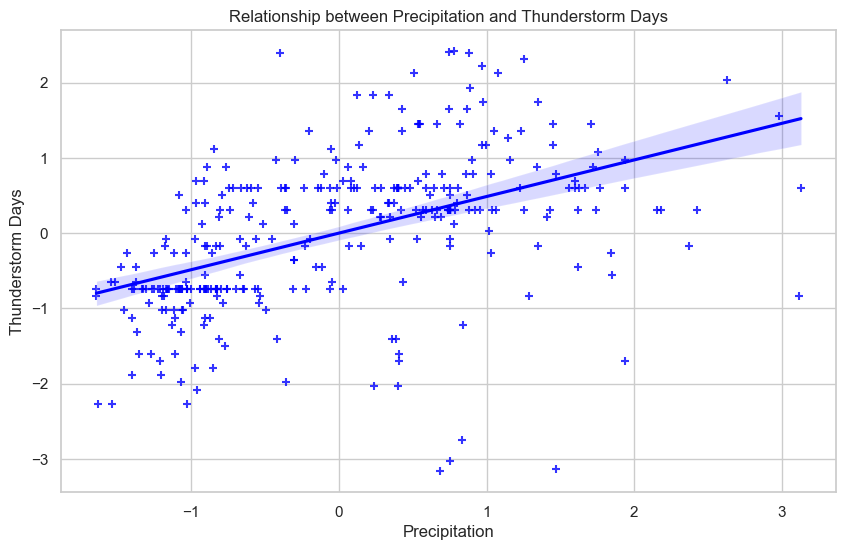

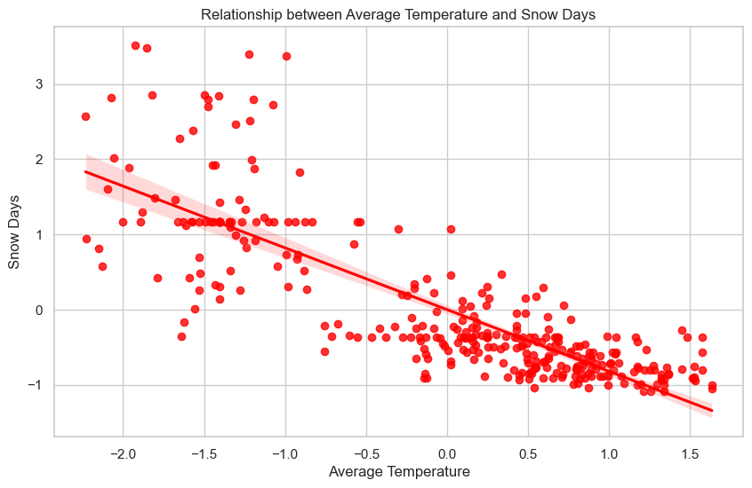

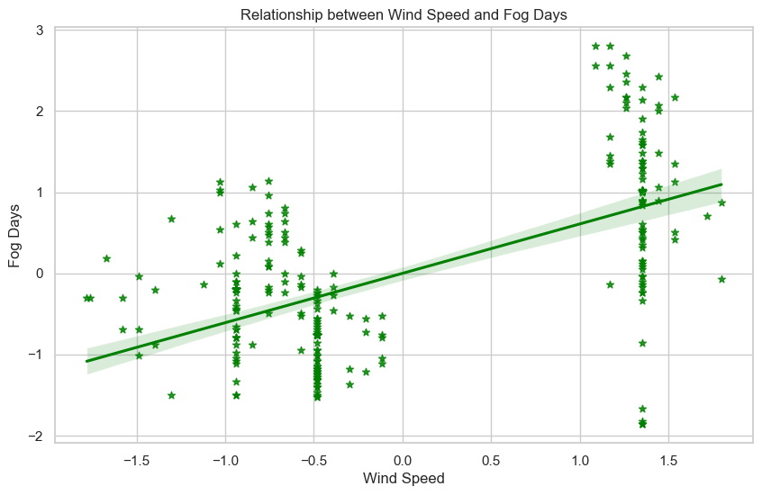

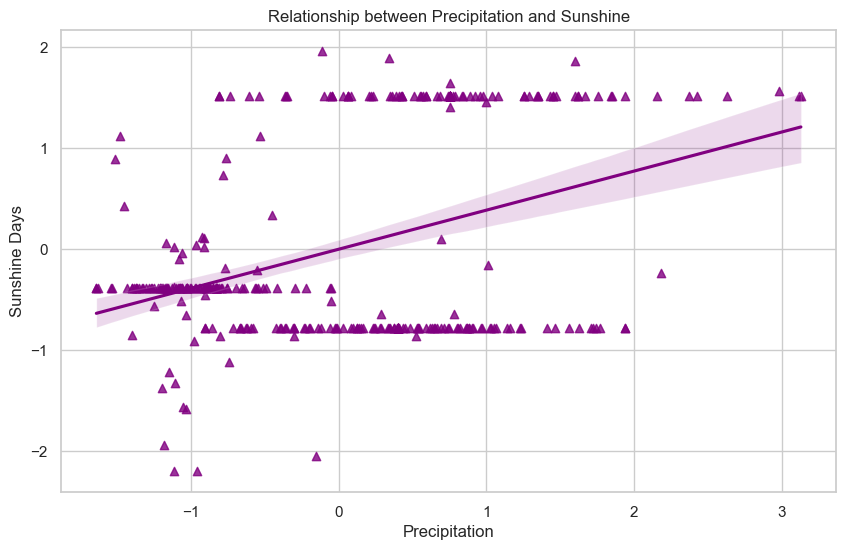

```python
# 1. Precipitation and Thunderstorm Days
plt.figure(figsize=(10, 6))
sns.regplot(x='PRCP', y='DYTS', data= merged_df, color='blue', marker='+')
plt.title('Relationship between Precipitation and Thunderstorm Days')
plt.xlabel('Precipitation')
plt.ylabel('Thunderstorm Days')
plt.show()

# 2. Temperature and Snow Days
plt.figure(figsize=(10, 6))
sns.regplot(x='TAVG', y='SNOW', data= merged_df, color='red', marker='o')
plt.title('Relationship between Average Temperature and Snow Days')
plt.xlabel('Average Temperature')
plt.ylabel('Snow Days')
plt.show()

# 3. Wind Speed and Fog Days
plt.figure(figsize=(10, 6))
sns.regplot(x='AWND', y='DYFG', data= merged_df, color='green', marker='*')
plt.title('Relationship between Wind Speed and Fog Days')
plt.xlabel('Wind Speed')
plt.ylabel('Fog Days')
plt.show()

# 4. Precipitation and Sunshine
plt.figure(figsize=(10, 6))
sns.regplot(x='PRCP', y='TSUN', data= merged_df, color='purple', marker='^')
plt.title('Relationship between Precipitation and Sunshine')
plt.xlabel('Precipitation')
plt.ylabel('Sunshine Days')
plt.show()
```

```python
# Hypotheses Testing with Regression Analysis
def run_regression(df, response, predictor):
    # Fit regression model
    formula = f'{response} ~ {predictor}'
    model = smf.ols(formula, data=merged_df).fit()
    print(model.summary())

# 1. Precipitation and Thunderstorm Days
if 'PRCP' in merged_df.columns and 'DYTS' in merged_df.columns:
    run_regression(df, 'DYTS', 'PRCP')

# 2. Average Temperature and Snow Days
if 'TAVG' in merged_df.columns and 'SNOW' in merged_df.columns:
    run_regression(df, 'SNOW', 'TAVG')

# 3. Wind Speed and Fog Days
if 'AWND' in merged_df.columns and 'DYFG' in merged_df.columns:
    run_regression(df, 'DYFG', 'AWND')

# 4. Precipitation and Sunshine
if 'PRCP' in merged_df.columns and 'TSUN' in merged_df.columns:
    run_regression(df, 'TSUN', 'PRCP')
```

```
                            OLS Regression Results
==============================================================================
Dep. Variable:                   DYTS   R-squared:                       0.236
Model:                            OLS   Adj. R-squared:                  0.234
Method:                 Least Squares   F-statistic:                     101.8
Date:                Sat, 18 May 2024   Prob (F-statistic):           5.00e-21
Time:                        22:38:50   Log-Likelihood:                -425.07
No. Observations:                 331   AIC:                             854.1
Df Residuals:                     329   BIC:                             861.7
Df Model:                           1
Covariance Type:            nonrobust
==============================================================================
                 coef    std err          t      P>|t|      [0.025      0.975]
------------------------------------------------------------------------------
Intercept   1.171e-16      0.048   2.43e-15      1.000      -0.095       0.095
PRCP           0.4860      0.048     10.088      0.000       0.391       0.581
==============================================================================
Omnibus:                       52.095   Durbin-Watson:                   1.092
Prob(Omnibus):                  0.000   Jarque-Bera (JB):              127.364
Skew:                          -0.764   Prob(JB):                     2.20e-28
Kurtosis:                       5.627   Cond. No.                         1.00
==============================================================================

Notes:
[1] Standard Errors assume that the covariance matrix of the errors is correctly specified.
                            OLS Regression Results
==============================================================================
Dep. Variable:                   SNOW   R-squared:                       0.673
Model:                            OLS   Adj. R-squared:                  0.672
Method:                 Least Squares   F-statistic:                     677.6
Date:                Sat, 18 May 2024   Prob (F-statistic):           6.86e-82
Time:                        22:38:50   Log-Likelihood:                -284.59
No. Observations:                 331   AIC:                             573.2
Df Residuals:                     329   BIC:                             580.8
Df Model:                           1
Covariance Type:            nonrobust
==============================================================================
                 coef    std err          t      P>|t|      [0.025      0.975]
------------------------------------------------------------------------------
Intercept   7.286e-17      0.032   2.31e-15      1.000      -0.062       0.062
```

[output cut: 45 more lines]

```
Covariance Type:            nonrobust
==============================================================================
                 coef    std err          t      P>|t|      [0.025      0.975]
------------------------------------------------------------------------------
Intercept   4.931e-16      0.051    9.7e-15      1.000      -0.100       0.100
PRCP           0.3865      0.051      7.600      0.000       0.286       0.486
==============================================================================
Omnibus:                       76.319   Durbin-Watson:                   0.352
Prob(Omnibus):                  0.000   Jarque-Bera (JB):               18.417
Skew:                           0.261   Prob(JB):                     0.000100
Kurtosis:                       1.969   Cond. No.                         1.00
==============================================================================

Notes:
[1] Standard Errors assume that the covariance matrix of the errors is correctly specified.
```

### Overview of Weather Prediction Models Using Machine Learning

The provided Python code outlines a comprehensive approach to predicting weather-related outcomes using multiple machine learning models. The process involves data preprocessing, feature selection, model initialization, model training, and evaluation of performance using different metrics. Below is a breakdown of what each section of the code does and how it contributes to weather prediction.

#### Data Preprocessing

- The script starts by filtering out warnings to ensure clean output.
- It selects numeric columns from a dataset and computes yearly averages for these, grouping by `DATE`.
- Features (independent variables) like temperature, precipitation, wind speed, etc., are defined, and targets (dependent variables) related to weather events are set.
- The dataset is split into training and testing subsets, and the features are standardized to have a mean of zero and a variance of one, enhancing the model's performance by ensuring that all features contribute equally.

#### Model Initialization and Training

- Several machine learning models are initialized, including:
  - **Decision Tree Regressor**: A model that predicts the value of a target variable by learning simple decision rules inferred from the feature data points.
  - **Support Vector Machine (SVM)**: Uses a representation of the training data in space and separates the categories by a clear gap that is as wide as possible.
  - **K-Nearest Neighbors (KNN)**: Predicts the output based on the majority of the K-nearest data points.
  - **Artificial Neural Network (ANN)**: Mimics the human brain and consists of neurons and weights. It learns from the data by adjusting the weights.
  - **Gradient Boosting Regressor**: Builds an additive model in a forward stage-wise fashion; it allows for the optimization of arbitrary differentiable loss functions.
- These models are trained using the training set and evaluated using cross-validation to assess their generalizability.

#### Model Evaluation

- Models are evaluated based on Mean Squared Error (MSE), Mean Absolute Error (MAE), and the R-squared (R2) statistic, which respectively measure the average squared difference between the estimated values and actual value, the average absolute difference, and the proportion of variance in the dependent variable predictable from the independent variables.
- Cross-validation results provide a robust estimate of the model's performance, averaging metrics over several subsets of the data to avoid overfitting.

#### Ensemble Techniques

- The script demonstrates how to create ensemble predictions by averaging the outputs of selected models. This method can reduce variance and bias, making the predictions more robust than those from a single model.
- Predictions are visually compared with actual values through plots, and ensemble performance is evaluated using the same metrics as individual models.

### How This Helps Weather Prediction

```python
import warnings
from sklearn.exceptions import ConvergenceWarning
warnings.filterwarnings("ignore", category=ConvergenceWarning)

numeric_columns = merged_df.select_dtypes(include=['float64', 'int64']).columns.drop('DATE')
yearly_data = merged_df.groupby('DATE')[numeric_columns].mean().reset_index()

# features and target variables
features = ['TMAX', 'TMIN', 'PRCP', 'SNOW', 'TAVG', 'AWND']
targets = ['DYHF', 'DYTS', 'TSUN', 'DYFG']

X = yearly_data[features]
y_dict = {target: yearly_data[target] for target in targets}

# Splitting the data into training and testing sets
X_train, X_test = train_test_split(X, test_size=0.2, random_state=42)

# Standardizing the features
scaler = StandardScaler()
X_train_scaled = scaler.fit_transform(X_train)
X_test_scaled = scaler.transform(X_test)

# models
models = {
    "Decision Tree": DecisionTreeRegressor(),
    "SVM": SVR(),
    "KNN": KNeighborsRegressor(),
    "ANN": MLPRegressor(max_iter=1000),
    "Gradient Boosting": GradientBoostingRegressor()
}

results = {}

# Training and evaluating the models using cross-validation
kf = KFold(n_splits=5, random_state=42, shuffle=True)

for target in targets:
    y_train, y_test = train_test_split(y_dict[target], test_size=0.2, random_state=42)

    for name, model in models.items():
        model.fit(X_train_scaled, y_train)
        y_pred = model.predict(X_test_scaled)
        mse = mean_squared_error(y_test, y_pred)
        mae = mean_absolute_error(y_test, y_pred)
        r2 = r2_score(y_test, y_pred)

        # Cross-validation scores
        cv_mse = -cross_val_score(model, X_train_scaled, y_train, cv=kf, scoring='neg_mean_squared_error').mean()
        cv_mae = -cross_val_score(model, X_train_scaled, y_train, cv=kf, scoring='neg_mean_absolute_error').mean()
        cv_r2 = cross_val_score(model, X_train_scaled, y_train, cv=kf, scoring='r2').mean()

        if name not in results:
            results[name] = {}

        results[name][target] = {'MSE': mse, 'MAE': mae, 'R2': r2, 'CV_MSE': cv_mse, 'CV_MAE': cv_mae, 'CV_R2': cv_r2}

#  results
results_df = pd.DataFrame.from_dict(results, orient='index').stack().unstack(level=0)
print(results_df)
```

```
                                          Decision Tree  \
DYHF  {'MSE': 0.48946728843741644, 'MAE': 0.49209102...
DYTS  {'MSE': 0.4666320803507319, 'MAE': 0.478618389...
TSUN  {'MSE': 0.09830623821086741, 'MAE': 0.17909667...
DYFG  {'MSE': 0.6979712134181609, 'MAE': 0.614815963...

                                                    SVM  \
DYHF  {'MSE': 0.20706078617901563, 'MAE': 0.28904731...
DYTS  {'MSE': 0.24871304774208255, 'MAE': 0.36196929...
TSUN  {'MSE': 0.05830864565617695, 'MAE': 0.17116713...
DYFG  {'MSE': 0.26066358168208154, 'MAE': 0.37712294...

                                                    KNN  \
DYHF  {'MSE': 0.179717083646366, 'MAE': 0.2767434140...
DYTS  {'MSE': 0.2736003728107842, 'MAE': 0.430330502...
TSUN  {'MSE': 0.06743538022773393, 'MAE': 0.15130495...
DYFG  {'MSE': 0.2560294146162497, 'MAE': 0.347675047...

                                                    ANN  \
DYHF  {'MSE': 0.19233214708480012, 'MAE': 0.27573315...
DYTS  {'MSE': 0.30604946966700475, 'MAE': 0.44560428...
TSUN  {'MSE': 0.048228167539883876, 'MAE': 0.1611538...
DYFG  {'MSE': 0.31126320907642463, 'MAE': 0.41031077...

                                      Gradient Boosting
DYHF  {'MSE': 0.2515404573887015, 'MAE': 0.345099756...
DYTS  {'MSE': 0.22180690147847934, 'MAE': 0.35889364...
TSUN  {'MSE': 0.07983638476430875, 'MAE': 0.18574745...
DYFG  {'MSE': 0.31424625652284094, 'MAE': 0.37409529...
```

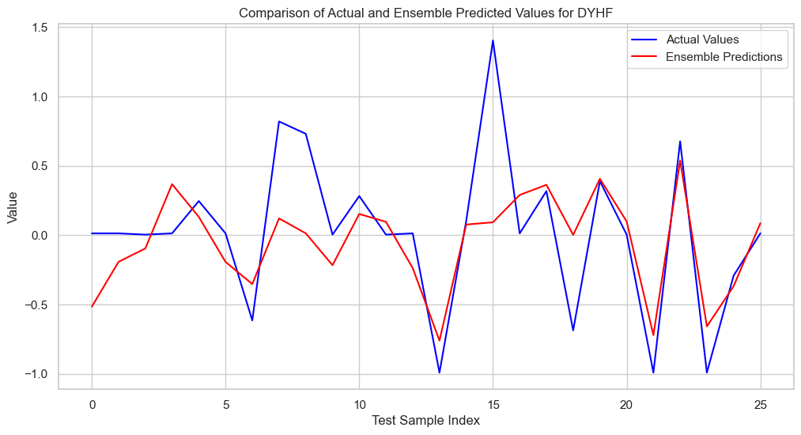

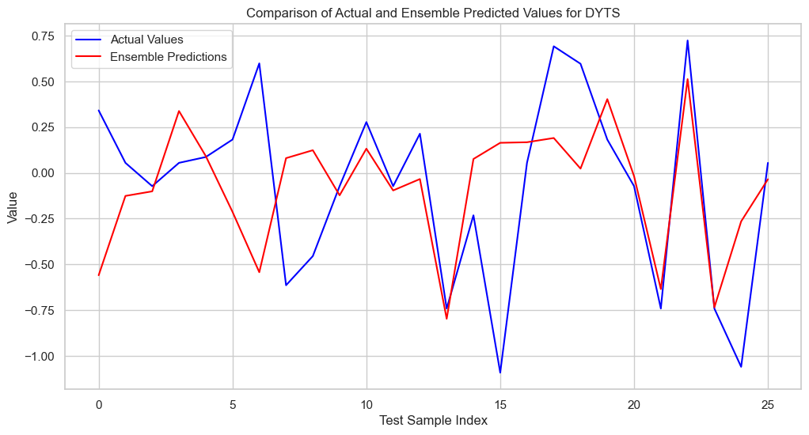

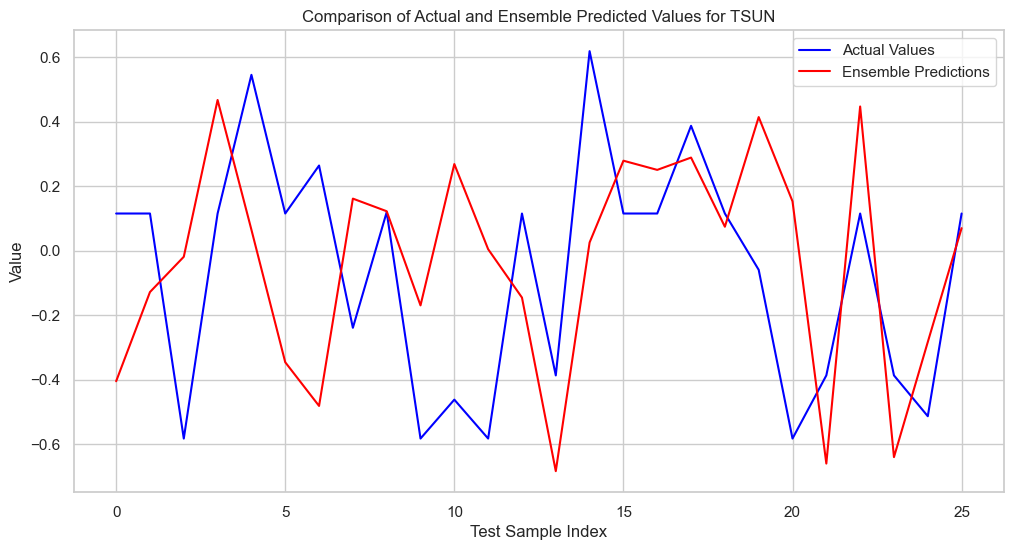

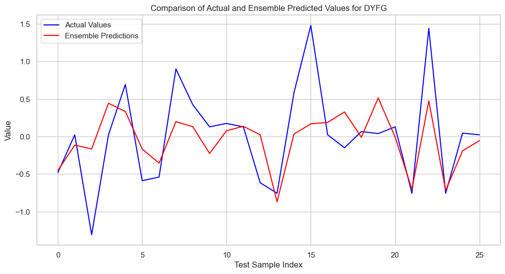

```
Performance for DYHF: MSE=0.16, MAE=0.29, R2=0.46
Performance for DYTS: MSE=0.24, MAE=0.34, R2=0.04
Performance for TSUN: MSE=0.18, MAE=0.36, R2=-0.41
Performance for DYFG: MSE=0.25, MAE=0.36, R2=0.40
```

```python
import numpy as np
import matplotlib.pyplot as plt
from sklearn.metrics import mean_squared_error, mean_absolute_error, r2_score
from sklearn.model_selection import train_test_split

# a dictionary to store ensemble predictions
ensemble_predictions = {}

# List of models to in the ensemble
included_models = ['SVM', 'KNN']

# ensemble predictions by averaging the predictions of the selected models
for target in targets:
    y_train, y_test = train_test_split(y_dict[target], test_size=0.2, random_state=42)
    predictions = []

    for name, model in models.items():
        if name in included_models:
            y_pred = model.predict(X_test_scaled)
            # Introducing noise to the predictions
            noise = np.random.normal(0, 0.1, size=y_pred.shape)
            predictions.append((y_pred + noise).reshape(-1, 1))


    ensemble_predictions[target] = np.mean(np.hstack(predictions), axis=1)

    # Plotting the actual vs predicted values for the ensemble
    plt.figure(figsize=(12, 6))
    plt.plot(y_test.values, label='Actual Values', color='blue')
    plt.plot(ensemble_predictions[target], label='Ensemble Predictions', color='red')
    plt.title(f'Comparison of Actual and Ensemble Predicted Values for {target}')
    plt.xlabel('Test Sample Index')
    plt.ylabel('Value')
    plt.legend()
    plt.show()

# ensemble performance
for target in targets:
    y_train, y_test = train_test_split(y_dict[target], test_size=0.2, random_state=42)
    mse = mean_squared_error(y_test, ensemble_predictions[target])
    mae = mean_absolute_error(y_test, ensemble_predictions[target])
    r2 = r2_score(y_test, ensemble_predictions[target])
    print(f'Performance for {target}: MSE={mse:.2f}, MAE={mae:.2f}, R2={r2:.2f}')
```

### Conclusion: Evaluating Machine Learning Models for Weather Prediction

#### Model Performance

The ensemble predictions exhibit some variance from the actual values, as seen in the plot. While the ensemble closely tracks the actual data's trend in some sections, it deviates in others, particularly around the peaks and troughs. This discrepancy could be due to the inherent limitations of the models used, the variability of the weather data itself, or possibly the need for further fine-tuning of the model parameters.

#### Future Directions

To further improve the model's accuracy, additional features could be integrated into the dataset, or more advanced ensemble techniques could be explored. Techniques such as model stacking or blending might provide better results by leveraging the distinct capabilities of different models more effectively. Furthermore, incorporating more data, especially from recent years or from more varied climatic conditions, could help refine the models' predictive capabilities.

#### Summary of the Tutorial

Overall, the approach outlined in this tutorial provides a strong foundation for using machine learning in weather prediction and can be adapted or expanded upon with newer techniques and data to meet specific forecasting needs.